# TP2

Mame Thierno NDIAYE

2024-04-12

```r
rm(list = ls())
```

```r
#install.packages("kableExtra")
library(tidyverse)
library(haven)
library(here)
library(readxl)
library(gtsummary)
library(ggplot2)
```

# 1 Importation et mise en forme

```r
path <- here()
base_tp2 <- read_excel(paste0(path, "/Base TP2.xlsx"))

#### Nombre de lignes
nLigne <- nrow(base_tp2)
print(nLigne)
```

```
## [1] 53
```

```r
#### Nombre de colonnes
nColonne<- ncol(base_tp2)
print(nColonne)
```

```
## [1] 30
```

# 2 Recodage et labelisation

```r
###### Labélisation des variables
base_tp2 <- base_tp2 %>%
  expss::apply_labels("region" = "Région",
                "departement" = "Département",
                "sexe" = "Sexe",
                "age" = "Age",
                "sit_mat" = "Situation maritale",
                "si_chef_men" = "Statut dans le ménage",
                "ethnie" = "Ethnie",
                "occupation" = "Occupation",
                "formation" = "Formation",
                "niveau_alphabs" = "Nveau d'alphabétisation",
                "sup_tot" = "Quelle est la superficie totale
                emblavée en sésame la saison passée ? EN
                HECTARES",
                "types_varietes" = "Quelles sont les variétés que
                vous utilisez pour la production de sésame",
                "var_trad" = "Si variétés traditionnelles, donnez
                les noms",
                "raison_var_trad" = "Pourquoi utilisez-vous les
                variétés traditionnelles",
                "var_amel" = "Si variétés améliorées, laquelle
                utilisez-vous ?",
                "raison_var_amel" = "Pourquoi utilisez-vous les
                variétés améliorées",
                "criteres_var" = "Quels sont les critères de choix
                des variétés se sésame ?",
                "types_varietes_1" = "Traditionnelles",
                "types_varietes_2" = "Améliorées")
base_tp2 <- base_tp2 %>%
     expss::apply_labels("criteres_var_1" = "rendements élevés",
                   "criteres_var_2" = "taille des graines",                            "criteres_var_3" = "résistantes aux
                         maladies/ravageurs",
                   "criteres_var_4" = "Tolérantes aux
                         sécheresses",
                   "criteres_var_5" = "Tolérantes aux inondations",
                   "criteres_var_6" = "Faibles quantités
                   d'intrants",
                   "criteres_var_7" = "Faibles charge de travail",
                   "criteres_var_8" = "facile à transformer",
                   "criteres_var_9" = "Haute teneur en huile",
                   "criteres_var_10" = "Haut rendement après
                   transformation",
                   "criteres_var_11" = "Demande sur le marché",
                   "criteres_var_12" = "Bon goût",
                   "criteres_var_13" = "Belle couleur",
                   "criteres_var_14" = "Haut rendement en
                   fourrages",
                   "criteres_var_15" = "Qualité du fourrage",
                   "criteres_var_16" = "autres à spécifier")


###### Recodage
base_tp2 <- base_tp2 %>%
  dplyr::mutate(sexe = dplyr::recode(sexe,
                                     "1" = "Homme",
                                     "2" = "Femme"))%>%
  dplyr::mutate(sit_mat = dplyr::recode(sit_mat,
                                     "1" = "Marié (e)",
                                     "3" = "Veuf (ve)",
                                     "4" = "Divorcé (e)",
                                     "5" = "Séparé (e)",
                                     "6" = "Célibataire"))%>%
 dplyr::mutate(si_chef_men = dplyr::recode(si_chef_men,
                                     "1" = "femme du chef de ménage",
                                     "2" = "chef de ménage",
                                     "3" = "fils-fille du chef de ménage",
                                     "99" = "Autres")) %>%
 dplyr::mutate(ethnie = dplyr::recode(ethnie,
                                     "1" = "Wolof",
                                     "2" = "Pulaar/Toucouleur",
                                     "3" = "Sérère",
                                     "4" = "Mandika/Bambara",
                                     "5" = "Soninké",
                                     "6" = "Diola",
                                     "7" = "Manjack",
                                     "8"= "Bainouk",
                                     "9" = "Maures",
                                     "10" = "Balante",
                                     "77" = "Autre")) %>%
  dplyr::mutate(occupation = dplyr::recode(occupation,
                                     "1" = "Agriculture, Elevage, Sylviculture, Pêche",
                                     "2" = "Activités extractives",
                                     "3" = "Activités de fabrication (Artisanat)",
                                     "4" = "Activité de transformation",
                                     "5" = "Production et distribution d'éléctricité et de gaz",
                                     "6" = "Production et distribution d'eau, assainissement, traitement des déchets et dépollution")) %>%
  dplyr::mutate(formation = dplyr::recode(formation,
                                     "1" = "Non scolarisé",
                                     "2" = "Élémentaires",
                                     "3" = "Moyen",
                                     "4" = "Secondaire",
                                     "5" = "Licence",
                                     "6" = "Master",
                                     "7" = "Doctorat",
                                     "99" = "Ne sait pas")) %>%
  dplyr::mutate(niveau_alphabs = dplyr::recode(niveau_alphabs,
                                     "0" = "Sans niveau",
                                     "1" = "Sais lire dans une langue",
                                     "2" = "Sais lire et écrire dans une langue"))
base_tp2 <- base_tp2 %>%
  dplyr::mutate(types_varietes_1=dplyr::recode(types_varietes_1,
                                          "0" = "Non",
                                          "1"= "Oui"))
base_tp2 <- base_tp2 %>%
  dplyr::mutate(types_varietes_2=dplyr::recode(types_varietes_2,
                                          "0" = "Non",
                                          "1" = "Oui"))
CritereVar <- base_tp2 %>%
  dplyr::select(gtsummary::starts_with("criteres_var_")) %>% names()
base_tp2 <- base_tp2 %>%
  dplyr::mutate(across(CritereVar, ~recode(.,
                                          "0" = "Non",
                                          "1"= "Oui")))
```

# 3 Analyses descriptives

##Statistiques univariées

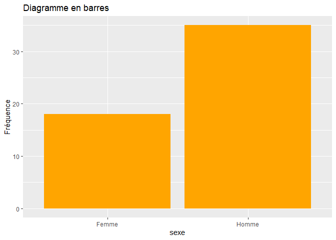

| **Variable** | **N = 53**<sup>1</sup> |
| --- | --- |
| sexe |  |
| Femme | 18.00 (33.96%) |
| Homme | 35.00 (66.04%) |

```r
univarie <- function(data, variable) {
  obj <- data[[variable]]

  if (is.numeric(obj)) {
    # Statistiques descriptives
    summary_table <- data %>%
      select({{ variable }}) %>%
      tbl_summary(
        type = {{ variable }} ~ "continuous2",
        statistic = list({{ variable }} ~ c("{mean}", "{sd}", "{median}", "{min}, {max}", "{p25}; {p75}", "{N_miss}; {p_miss}")),
        digits = {{ variable }} ~ 2
      ) %>%
      bold_labels() %>%
      modify_header(label = "**Variable**")
    # Histogramme
    hist_plot <- ggplot(data, aes(x = !!rlang::sym(variable))) +
      geom_histogram(color = "black", fill = "orange") +
      labs(title = "Histogramme", x = variable, y = "Fréquence")

    # Boîte à moustaches
    box_plot <- ggplot(data, aes(y = !!rlang::sym(variable))) +
      geom_boxplot(fill = "blue") +
      labs(title = "Boîte à moustaches", x = "", y = "Quantiles")
    print(hist_plot)
    print(box_plot)
    summary_table
  } else if (!is.numeric(obj)) {
    # Statistiques descriptives
    summary_table <- data %>%
      select({{ variable }}) %>%
      tbl_summary(
        statistic = list({{ variable }} ~ "{n} ({p}%)"),
        digits = {{ variable }} ~ 2
      ) %>%
      bold_labels() %>%
      modify_header(label = "**Variable**")

    # Diagramme en barres
    bar_plot <- ggplot(data, aes(x = !!rlang::sym(variable))) +
      geom_bar(fill = "orange") +
      labs(title = "Diagramme en barres", x = variable, y = "Fréquence")
    print(bar_plot)
    summary_table
  }
}

univarie(base_tp2, "sexe")
```

<sup>1</sup> n (%)

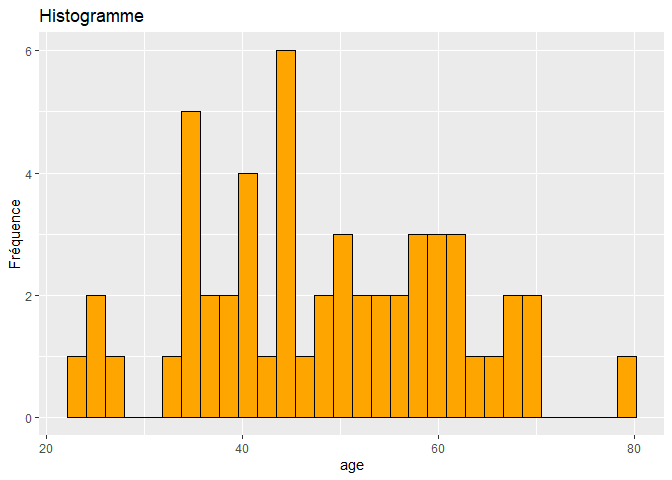

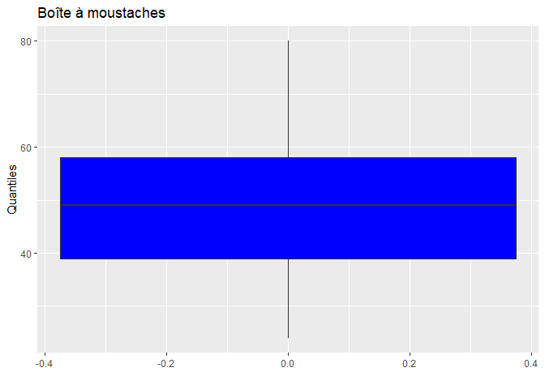

| **Variable** | **N = 53** |
| --- | --- |
| Age |  |
| Mean | 48.60 |
| SD | 12.91 |
| Median | 49.00 |
| Range | 24.00, 80.00 |
| 25%; 75% | 39.00; 58.00 |
| N missing; % missing | 0.00; 0.00 |

```r
univarie(base_tp2, "age")
```

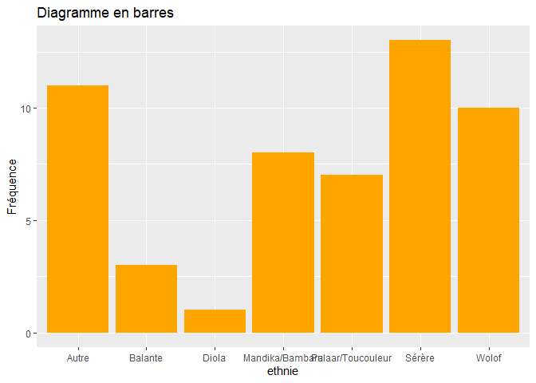

| **Variable** | **N = 53**<sup>1</sup> |
| --- | --- |
| ethnie |  |
| Autre | 11.00 (20.75%) |
| Balante | 3.00 (5.66%) |
| Diola | 1.00 (1.89%) |
| Mandika/Bambara | 8.00 (15.09%) |
| Pulaar/Toucouleur | 7.00 (13.21%) |
| Sérère | 13.00 (24.53%) |
| Wolof | 10.00 (18.87%) |

```r
univarie(base_tp2, "ethnie")
```

<sup>1</sup> n (%)

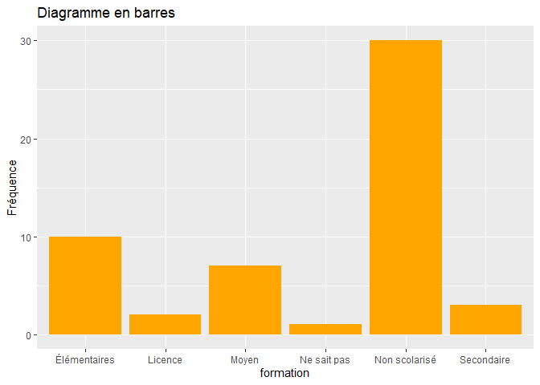

| **Variable** | **N = 53**<sup>1</sup> |
| --- | --- |
| formation |  |
| Élémentaires | 10.00 (18.87%) |
| Licence | 2.00 (3.77%) |
| Moyen | 7.00 (13.21%) |
| Ne sait pas | 1.00 (1.89%) |
| Non scolarisé | 30.00 (56.60%) |
| Secondaire | 3.00 (5.66%) |

```r
univarie(base_tp2, "formation")
```

<sup>1</sup> n (%)

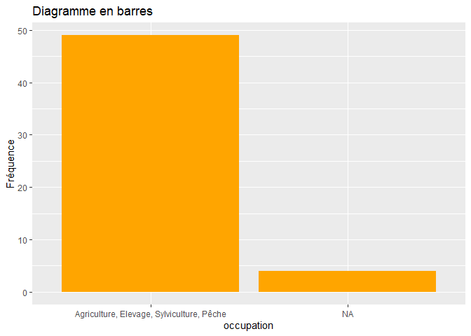

| **Variable** | **N = 53**<sup>1</sup> |
| --- | --- |
| occupation |  |
| Agriculture, Elevage, Sylviculture, Pêche | 49.00 (100.00%) |
| Unknown | 4 |

```r
univarie(base_tp2, "occupation")
```

<sup>1</sup> n (%)

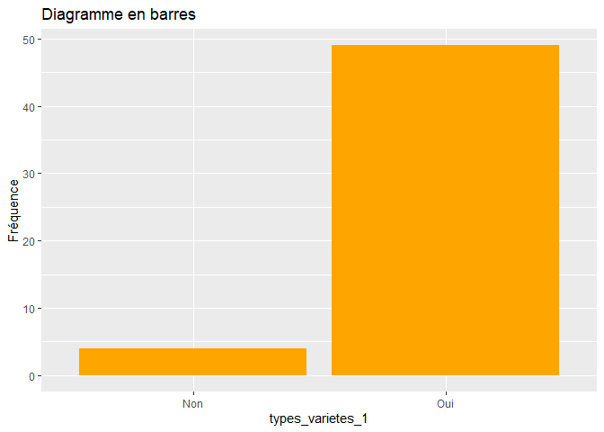

| **Variable** | **N = 53**<sup>1</sup> |
| --- | --- |
| types_varietes_1 |  |
| Non | 4.00 (7.55%) |
| Oui | 49.00 (92.45%) |

```r
univarie(base_tp2, "types_varietes_1")
```

<sup>1</sup> n (%)

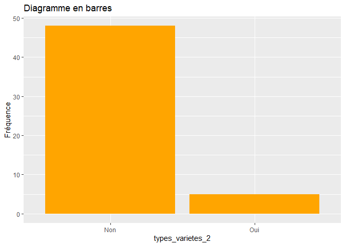

| **Variable** | **N = 53**<sup>1</sup> |
| --- | --- |
| types_varietes_2 |  |
| Non | 48.00 (90.57%) |
| Oui | 5.00 (9.43%) |

```r
univarie(base_tp2, "types_varietes_2")
```

<sup>1</sup> n (%)

```r
base_tp2 %>%
      gtsummary::tbl_cross(
        col = types_varietes_1,
        row = types_varietes_2,
        percent = "n"
      )
```

|  | types_varietes_1 Non | types_varietes_1 Oui | Total |  |
| --- | --- | --- | --- | --- |
| types_varietes_2 |  |  |  |  |
| Non | 0 | 48 | 48 |  |
| Oui | 4 | 1 | 5 |  |
| Total | 4 | 49 | 53 |  |

L’analyse des données révèle une prédominance masculine dans l’échantillon étudié, avec 66,04% d’hommes recensés. Tous les individus appartiennent à l’état matrimonial “marié”, affichant une moyenne d’âge de 48 ans avec une variabilité de 13 ans. La communauté sérère constitue la majorité, représentant 24,53% de l’échantillon, tandis que les Wolofs, Mandika/Bambara et Pulaar/Toucouleur sont également significativement représentés, avec des pourcentages respectifs de 18,87%, 15,09% et 13,21%.

En ce qui concerne les activités principales de cette population, l’agriculture, l’élevage, la sylviculture et la pêche sont les plus répandues et dominantes.

Concernant la production de sésame, presque tous les individus de l’échantillon (90,56%) utilisent exclusivement la variété traditionnelle, tandis que 7,54% ont recours uniquement à la variété améliorée. Seulement un individu de l’échantillon combine les deux variétés dans sa production.

##Statistiques bivariées

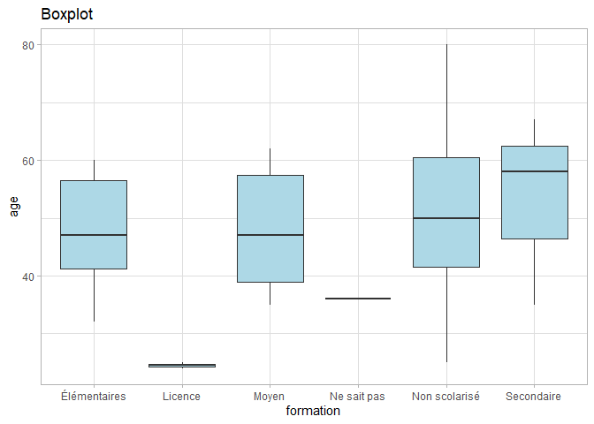

```r
###### Fonction pour sortir les stats univariées #######

bivarie <- function(data, var_1, var_2 ){
  obj_1 <- data[[var_1]]
  obj_2 <- data[[var_2]]

  #### Deux variables quantitatives ########
  if ((is.numeric(obj_1)) && (is.numeric(obj_2))){
    ##### Tests de corrélation #####
    m <- stats::lm(as.formula(paste(var_1, "~", var_2)), data = data)
    test <- m %>%
      gtsummary::tbl_regression() %>% #des résultats de la régression linéaire
      gtsummary::add_glance_source_note() %>%  #stats en notes du tableau
      modify_header(label = "**Variable**")
  ##### Nuage de points ######
   graph <- ggplot2::ggplot(data) +
    aes(x = !!rlang::sym(var_1), y = !!rlang::sym(var_2)) +
    geom_smooth(method="lm") +  # Droite de regréssion
    geom_point(colour = "blue", alpha = .25) +
    ggtitle("Nuage de points")+
    theme_light()
    print(graph)
    test
  }

    #### Variable quantitative et qualitative ########
  if ((is.numeric(obj_1)) && (!is.numeric(obj_2))){
  ##### tableau statistique ######
   tab <- data %>%
      tbl_summary(
        include = var_1,
        by = var_2,
        type = var_1 ~ "continuous2",
        statistic = list(var_1 ~ c("{N_nonmiss}; {p_miss}",
                            "{mean} ({sd})", "{median}","{p25}; {p75}")),
        digits = var_1 ~ 2
      ) %>%
    gtsummary::add_p() %>%  #Ajouter p_value
    modify_header(label = "**Variable**")
   ##### Boîtes à moustaches ######
    graph <- ggplot2::ggplot(data) +
      aes(x = !!rlang::sym(var_2), y = !!rlang::sym(var_1)) +
      geom_boxplot(fill = "lightblue") +
      ggtitle("Boxplot")+
      theme_light()

    print(graph)
    tab
  }
  if (!is.numeric(obj_1) && is.numeric(obj_2)){
    errorCondition("C'est la première variable doit être numérique")
  }

  #### Deux variables qualitatives ########
  if (!is.numeric(obj_1) && !is.numeric(obj_2)){
  ##### tableau statistique ######
   tab <- data %>%
      gtsummary::tbl_cross(
        col = var_1,
        row = var_2,
        percent = "cell"
      ) %>%
    gtsummary::add_p(source_note = TRUE)   #Ajouter p_value

  ##### Graphes ######
    graph <- ggplot(data) +
     aes(x = !!rlang::sym(var_1), fill = !!rlang::sym(var_2)) +
     geom_bar(position = "dodge") +
     scale_fill_hue(direction = 1) +
     labs(y = "Fréquence", caption = "Graphique") +
     theme_light()
    print(graph)
    tab
  }
}

bivarie(base_tp2, "age", "formation")
```

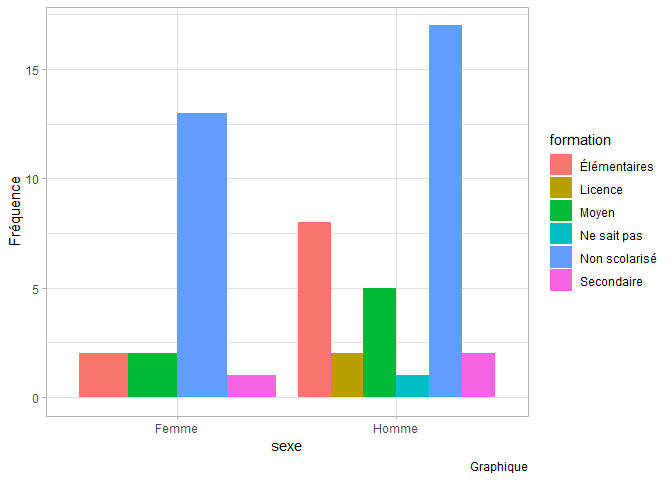

|  | sexe Femme | sexe Homme | Total |  |
| --- | --- | --- | --- | --- |
| formation |  |  |  |  |
| Élémentaires | 2 (3.8%) | 8 (15%) | 10 (19%) |  |
| Licence | 0 (0%) | 2 (3.8%) | 2 (3.8%) |  |
| Moyen | 2 (3.8%) | 5 (9.4%) | 7 (13%) |  |
| Ne sait pas | 0 (0%) | 1 (1.9%) | 1 (1.9%) |  |
| Non scolarisé | 13 (25%) | 17 (32%) | 30 (57%) |  |
| Secondaire | 1 (1.9%) | 2 (3.8%) | 3 (5.7%) |  |
| Total | 18 (34%) | 35 (66%) | 53 (100%) |  |

```r
bivarie(base_tp2, "sexe", "formation")
```

Fisher’s exact test, p=0.7

```r
chisq.test(base_tp2$age, base_tp2$formation)
```

```
##
##  Pearson's Chi-squared test
##
## data:  base_tp2$age and base_tp2$formation
## X-squared = 165.47, df = 150, p-value = 0.1834
```

Les résultats révèlent une homogénéité relative de la moyenne d’âge parmi les différents niveaux d’éducation, avec une moyenne avoisinant la cinquantaine pour la plupart. Cela suggère une relation indépendante entre l’âge et le niveau d’éducation. Ce constat est confirmé par une p-value de 0,2. La répartition du niveau d’éducation selon le sexe montre également une indépendance entre les deux variables. Une p-value de 0,7 confirme ce résultat.